# MTH6139 Time Series

Coursework 1 – Selim Elmas

Selim Elmas

Spring term 2025

# Section 1: Introduction

## Overview

With this project we would like to investigate and compare the relationship between **crude oil prices** and **Euro/Usd exchange rate**. I will look both at the closing price and daily returns.

Since Oil prices are quoted in US dollars globally, if the dollar becomes weaker the prices of oil becomes cheaper. Additonally, a weaker dollar means the Euro is worth more in dollar terms.

Using the ‘tidyquant’ package we will be able to retrieve stock data from Yahoo Finance, and then apply **Prophet** forecasting model.

## Data Loading

```r
library(prophet)
library(zoo)
library(tidyquant)
library(ggplot2)
library(dplyr)
library(tidyr)
```

## Data Preparation

“CL=F” is the crude oil futures (USD per barrel)

“EUR/USD=X” is Euro quoted in US dollars

We will be looking at data from “2024-01-01” til now.

```r
symbols <- c("CL=F", "EURUSD=X")

price_data <- tq_get(symbols,
                     get  = "stock.prices",
                     from = "2024-01-01",
                     to   = Sys.Date())
```

Taking a look at the first and last 5 entries of our DataFrame aswell as the structure.

```r
head(price_data)
```

```
## # A tibble: 6 × 8
##   symbol date        open  high   low close volume adjusted
##   <chr>  <date>     <dbl> <dbl> <dbl> <dbl>  <dbl>    <dbl>
## 1 CL=F   2024-01-02  71.7  73.6  70.1  70.4 330992     70.4
## 2 CL=F   2024-01-03  70.5  73.2  69.3  72.7 334861     72.7
## 3 CL=F   2024-01-04  73.0  74    71.1  72.2 344467     72.2
## 4 CL=F   2024-01-05  72.4  74.2  72.2  73.8 325525     73.8
## 5 CL=F   2024-01-08  73.5  73.9  70.1  70.8 392249     70.8
## 6 CL=F   2024-01-09  70.9  72.9  70.5  72.2 363445     72.2
```

```r
tail(price_data)
```

```
## # A tibble: 6 × 8
##   symbol   date        open  high   low close volume adjusted
##   <chr>    <date>     <dbl> <dbl> <dbl> <dbl>  <dbl>    <dbl>
## 1 EURUSD=X 2026-03-16  1.14  1.15  1.14  1.14      0     1.14
## 2 EURUSD=X 2026-03-17  1.15  1.15  1.15  1.15      0     1.15
## 3 EURUSD=X 2026-03-18  1.15  1.16  1.15  1.15      0     1.15
## 4 EURUSD=X 2026-03-19  1.15  1.15  1.14  1.15      0     1.15
## 5 EURUSD=X 2026-03-20  1.16  1.16  1.15 NA         0    NA
## 6 EURUSD=X 2026-03-20  1.16  1.16  1.15  1.15      0     1.15
```

```r
glimpse(price_data)
```

```
## Rows: 1,140
## Columns: 8
## $ symbol   <chr> "CL=F", "CL=F", "CL=F", "CL=F", "CL=F", "CL=F", "CL=F", "CL=F…
## $ date     <date> 2024-01-02, 2024-01-03, 2024-01-04, 2024-01-05, 2024-01-08, …
## $ open     <dbl> 71.71, 70.50, 73.04, 72.40, 73.51, 70.91, 72.17, 71.33, 73.01…
## $ high     <dbl> 73.64, 73.23, 74.00, 74.24, 73.95, 72.93, 73.59, 73.81, 75.25…
## $ low      <dbl> 70.06, 69.28, 71.06, 72.21, 70.13, 70.47, 71.01, 71.17, 72.36…
## $ close    <dbl> 70.38, 72.70, 72.19, 73.81, 70.77, 72.24, 71.37, 72.02, 72.68…
## $ volume   <dbl> 330992, 334861, 344467, 325525, 392249, 363445, 352772, 37364…
## $ adjusted <dbl> 70.38, 72.70, 72.19, 73.81, 70.77, 72.24, 71.37, 72.02, 72.68…
```

‘tq_get’ returns one row per symbol per trading day. The columns we care about most are ‘symbol’, `date`, `close`, and `adjusted`.

### Comparing Data

For comparison, we will reshape the data so Oil and Euro both have their own column and will only be looking at the adjusted closing price.

```r
compare <- price_data %>%
    select(symbol,date,adjusted) %>%
    pivot_wider(names_from = symbol,values_from=adjusted) %>%
    rename(OIL = "CL=F",EURO = "EURUSD=X") %>%
    unnest(cols=c(OIL,EURO))
```

Looking at the first 5 entries.

```r
head(compare)
```

```
## # A tibble: 6 × 3
##   date         OIL  EURO
##   <date>     <dbl> <dbl>
## 1 2024-01-02  70.4  1.10
## 2 2024-01-03  72.7  1.09
## 3 2024-01-04  72.2  1.09
## 4 2024-01-05  73.8  1.09
## 5 2024-01-08  70.8  1.09
## 6 2024-01-09  72.2  1.10
```

# Exploratory Analysis

## Adjusted Prices

Since there is a discrepancy between the closing price of the two instruments, we will use `scales = "free_y"` so each panel has its own y-axis.

The following chart shows the adjusted closing prices of Oil and Euro on separate panels.

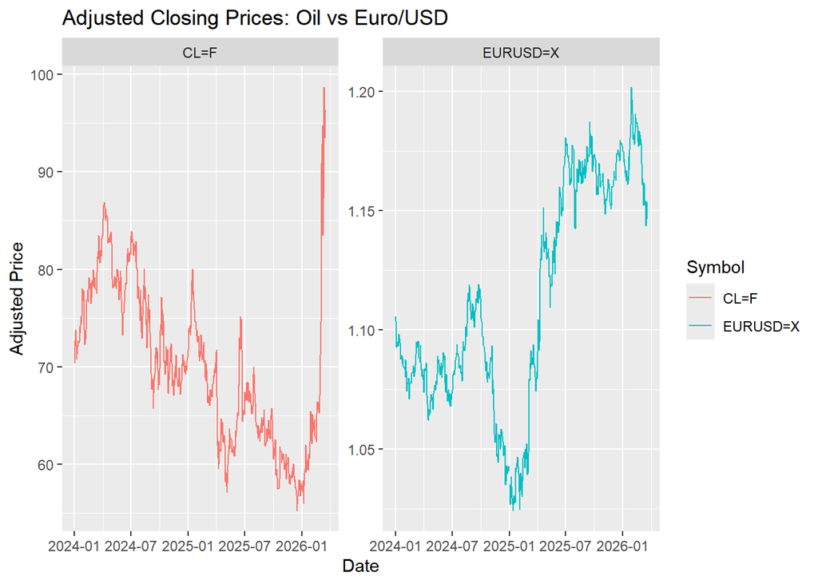

```r
ggplot(price_data, aes(x = date, y = adjusted, color = symbol)) +
  geom_line() +
  facet_wrap(~symbol, scales = "free_y") +
  labs(title  = "Adjusted Closing Prices: Oil vs Euro/USD",
       x      = "Date",
       y      = "Adjusted Price",
       color  = "Symbol")
```

```r
lm_euro <- lm(EURO ~ OIL, data=compare)
summary(lm_euro)
```

```
##
## Call:
## lm(formula = EURO ~ OIL, data = compare)
##
## Residuals:
##       Min        1Q    Median        3Q       Max
## -0.077521 -0.019971  0.000987  0.021961  0.132354
##
## Coefficients:
##               Estimate Std. Error t value Pr(>|t|)
## (Intercept)  1.3376532  0.0150197   89.06   <2e-16 ***
## OIL         -0.0032199  0.0002128  -15.13   <2e-16 ***
## ---
## Signif. codes:  0 '***' 0.001 '**' 0.01 '*' 0.05 '.' 0.1 ' ' 1
##
## Residual standard error: 0.03906 on 495 degrees of freedom
##   (143 observations deleted due to missingness)
## Multiple R-squared:  0.3163, Adjusted R-squared:  0.3149
## F-statistic:   229 on 1 and 495 DF,  p-value: < 2.2e-16
```

According to the model, we observe that both parameters (Oil and intercept) are statistically significant at the 5% level. The R-squared of 0.316 means that Oil price explains roughly **31.6%** of the variation in the Euro rate. From this, we see there is a moderate relationship between the two.

## Normalised Prices

We normalise both series so they start at 1.0 on the first trading day.

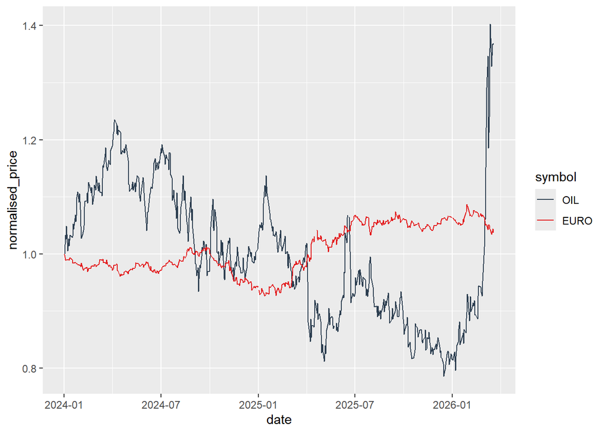

```r
price_data %>%
    group_by(symbol) %>%
    mutate(normalised_price = adjusted / first(adjusted)) %>%
    ggplot(aes(x = date, y=normalised_price, color=symbol))+
    geom_line() +
    scale_color_tq(labels = c("CL=F" = "OIL", "EURUSD=X" = "EURO"))
```

```r
    labs(title = "EURO vs OIL")
```

```
## <ggplot2::labels> List of 1
##  $ title: chr "EURO vs OIL"
```

# Daily Returns

Moving away from adjusted prices, we now look at the **daily percentage returns**.

```r
returns <- price_data %>%
    group_by(symbol)%>%
    tq_transmute(mutate_fun = periodReturn,period="daily",col_rename = "returns") %>%
    pivot_wider(names_from = symbol,values_from=returns) %>%
    rename(OIL_Return = "CL=F",EURO_Return = "EURUSD=X")
head(returns)
```

```
## # A tibble: 6 × 3
##   date       OIL_Return EURO_Return
##   <date>          <dbl>       <dbl>
## 1 2024-01-02   -0.0185    -0.00155
## 2 2024-01-03    0.0330    -0.00879
## 3 2024-01-04   -0.00702   -0.00128
## 4 2024-01-05    0.0224     0.00180
## 5 2024-01-08   -0.0412    -0.000471
## 6 2024-01-09    0.0208     0.000865
```

### Daily Percentage Return Plot

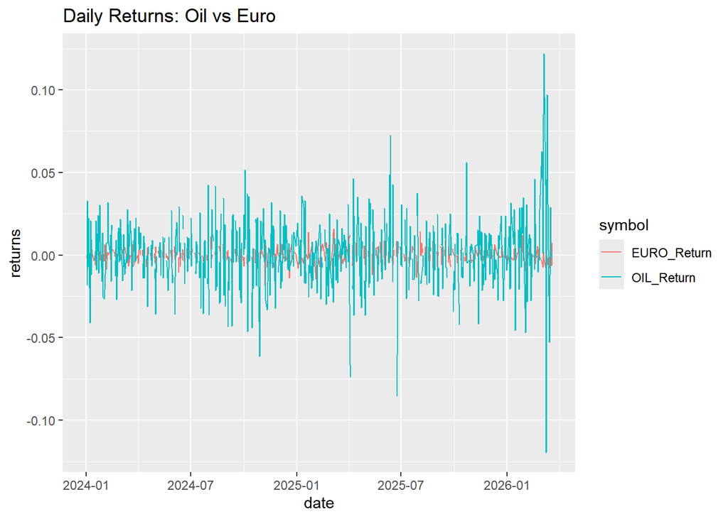

```r
returns %>%
    pivot_longer(cols = c(OIL_Return, EURO_Return),
               names_to = "symbol",
               values_to = "returns") %>%
    ggplot(aes(x = date, y = returns, color = symbol)) +
    geom_line() +
    labs(title = "Daily Returns: Oil vs Euro")
```

From the chart, we can see that **Oil returns are considerably more volatile** than Euro returns. Oil frequently shows large spikes both upward and downward, while the Euro remains in a much narrower band. This highlights how volatile Oil returns are, its more susceptible to supply shocks, geopolitical tensions etc.

## Prophet Forecasting

We create two separate Prophet-compatible data frames. Prophet requires the date column to be named `ds` and the value column to be named `y`.

```r
oil_returns_df <- returns %>%
  select(ds = date, y = OIL_Return)

euro_returns_df <- returns %>%
  select(ds = date, y = EURO_Return)
```

### Forecasting Oil Returns

```r
model_oil    <- prophet(oil_returns_df)
future_oil   <- make_future_dataframe(model_oil, periods = 100)
forecast_oil <- predict(model_oil, future_oil)
```

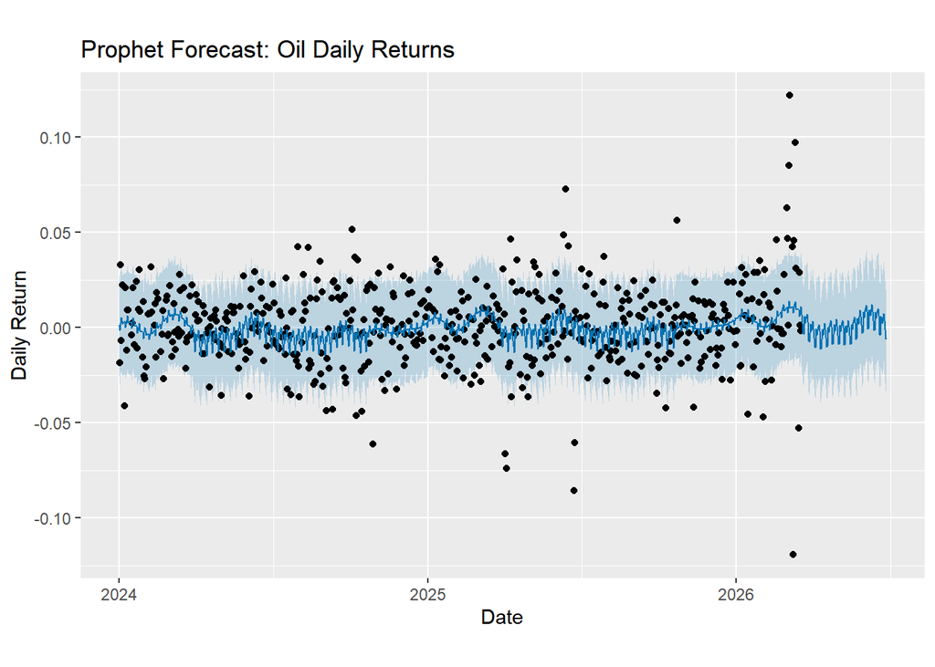

```r
plot(model_oil, forecast_oil) +
  labs(title = "Prophet Forecast: Oil Daily Returns",
       x     = "Date",
       y     = "Daily Return")
```

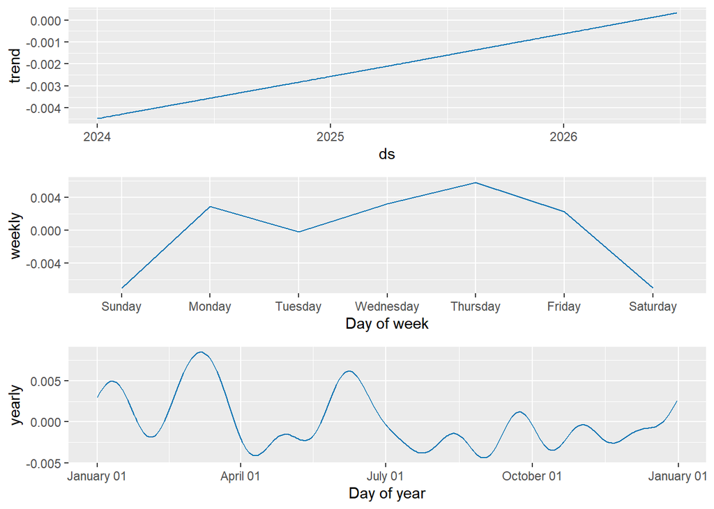

```r
prophet_plot_components(model_oil, forecast_oil)
```

From the plot, we can see the general trend for the mean return has been drifiting upwards in our time period. We also see that the mean return tends to be higher on Thursday compared to any other days of the week.

The shaded blue region is also quite wide, reflecting the volatile nature of Oil.

### Forecasting Euro Returns

```r
model_euro    <- prophet(euro_returns_df)
future_euro   <- make_future_dataframe(model_euro, periods = 100)
forecast_euro <- predict(model_euro, future_euro)
```

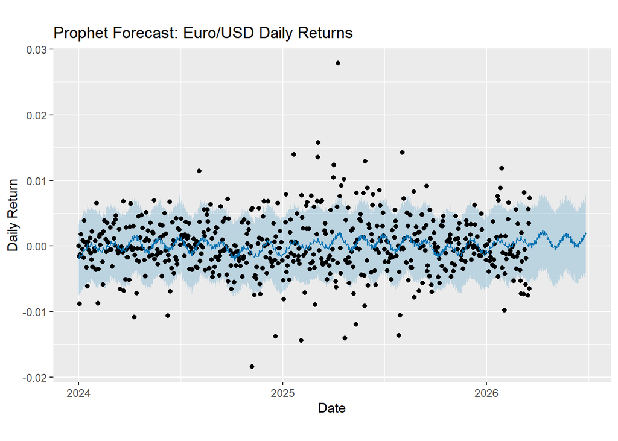

```r
plot(model_euro, forecast_euro) +
  labs(title = "Prophet Forecast: Euro/USD Daily Returns",
       x     = "Date",
       y     = "Daily Return")
```

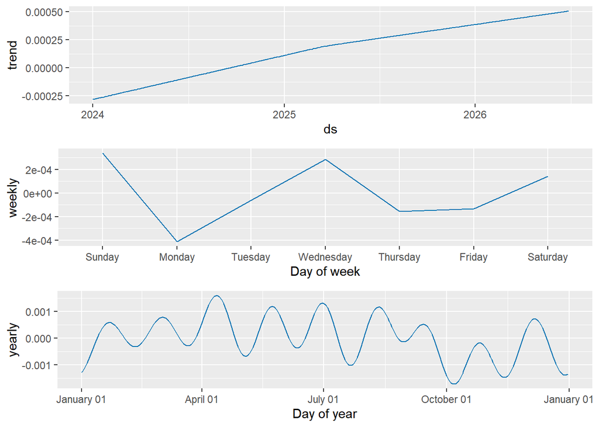

```r
prophet_plot_components(model_euro, forecast_euro)
```

Compared to the Oil forecast, the uncertainty band for the Euro is narrower, reflecting the lower volatility of the instrument.